# Stock-performance-basic

John Yuill

2020-12-30

## Get price data

Getting daily price data for any stock is as easy as using quantmod package and getSymbols function.

- fetches data as xts time series object
- note src and updated in str output

```r
getSymbols("CSIQ", auto.assign=TRUE) ## auto.assign=TRUE saves object; FALSE prints out data
```

```
## [1] "CSIQ"
```

```r
str(CSIQ)
```

```
## An 'xts' object on 2007-01-03/2020-12-29 containing:
##   Data: num [1:3523, 1:6] 11 10.8 10.5 10.1 10 ...
##  - attr(*, "dimnames")=List of 2
##   ..$ : NULL
##   ..$ : chr [1:6] "CSIQ.Open" "CSIQ.High" "CSIQ.Low" "CSIQ.Close" ...
##   Indexed by objects of class: [Date] TZ: UTC
##   xts Attributes:
## List of 2
##  $ src    : chr "yahoo"
##  $ updated: POSIXct[1:1], format: "2020-12-30 18:20:24"
```

Entire history of the daily stock price (at least going back to 2007) is now available in an xts object named after the stock symbol.

- default source is yahoo finance (src=‘yahoo’)
- default start date is ‘2007-01-01’ (from=‘2007-01-01’)

Provides daily Open, High, Low, Close, Volume, Adjusted (aka OHLCVA):

```r
## show first rows
head(CSIQ)
```

```
##            CSIQ.Open CSIQ.High CSIQ.Low CSIQ.Close CSIQ.Volume
## 2007-01-03     10.98     11.00    10.65      10.82      176300
## 2007-01-04     10.82     10.82    10.39      10.41      164100
## 2007-01-05     10.50     10.70    10.12      10.15       68600
## 2007-01-08     10.10     10.34     9.95       9.98      195500
## 2007-01-09     10.00     10.05     9.77       9.77       85900
## 2007-01-10      9.69      9.97     9.61       9.68       77800
##            CSIQ.Adjusted
## 2007-01-03         10.82
## 2007-01-04         10.41
## 2007-01-05         10.15
## 2007-01-08          9.98
## 2007-01-09          9.77
## 2007-01-10          9.68
```

```r
## show last rows
tail(CSIQ)
```

```
##            CSIQ.Open CSIQ.High CSIQ.Low CSIQ.Close CSIQ.Volume
## 2020-12-21     44.68     48.67    44.22      47.98     2863000
## 2020-12-22     49.49     53.19    49.20      53.16     5286000
## 2020-12-23     54.45     56.42    52.28      52.93     3634700
## 2020-12-24     52.68     54.50    50.70      52.71     1332700
## 2020-12-28     54.35     55.34    50.28      51.26     1972200
## 2020-12-29     51.09     51.23    48.07      49.51     2069700
##            CSIQ.Adjusted
## 2020-12-21         47.98
## 2020-12-22         53.16
## 2020-12-23         52.93
## 2020-12-24         52.71
## 2020-12-28         51.26
## 2020-12-29         49.51
```

“Adjusted” = prices adjusted for stock splits and dividends (possibly other developments? major new issues? buy-backs?)

### Incl. TSX

- Includes stocks on TSX
- Optionally import into specified object.
- Specify src from variety of available data sources

```r
## specify object with auto.assign=FALSE
ogi <- getSymbols(Symbols='OGI.TO', auto.assign=FALSE, src='yahoo')
```

### Filter for time period

- When importing: specific period (start date and end date)

```r
getSymbols("CSIQ", from="2018-01-01", to=Sys.Date(), auto.assign = TRUE)
```

```
## [1] "CSIQ"
```

```r
CSIQ_2018 <- CSIQ

head(CSIQ_2018)
```

```
##            CSIQ.Open CSIQ.High CSIQ.Low CSIQ.Close CSIQ.Volume
## 2018-01-02     16.98     17.16    16.88      17.14      736100
## 2018-01-03     17.18     17.20    16.83      17.07      987600
## 2018-01-04     17.13     17.16    16.78      17.06      799100
## 2018-01-05     17.00     17.19    16.90      17.01      768900
## 2018-01-08     17.03     17.20    16.85      17.10      727100
## 2018-01-09     17.08     17.09    16.72      16.95      725500
##            CSIQ.Adjusted
## 2018-01-02         17.14
## 2018-01-03         17.07
## 2018-01-04         17.06
## 2018-01-05         17.01
## 2018-01-08         17.10
## 2018-01-09         16.95
```

```r
## reset full CSIQ for later
getSymbols("CSIQ", auto.assign = TRUE)
```

```
## [1] "CSIQ"
```

- filter after import

```r
CSIQ_2020 <- CSIQ['2020-01-01/'] ## from specified date fwd
CSIQ_90d <- tail(CSIQ, n=90) ## last n

## selected period
CSIQ_Aug <- CSIQ['2020-08/2020-08-31'] ## Aug 1-31
```

- filter with first and last functions in xts

```r
## data in last 3 months (calendar mths, data so far)
CSIQ_3_mth <- last(CSIQ, "3 months" )
## combine first & last to get: first week from last (mont recent) year
## - includes the days of week 1 in the year
CSIQ_first_week <- first(last(CSIQ, "1 year"), "1 week")
```

More Time Series Manipulation examples with xts below in separate section.

### Get multiple stocks

Each imported as separate object

```r
getSymbols(c("NEP","SPWR"), auto.assign = TRUE)
```

```
## [1] "NEP"  "SPWR"
```

```r
## OR
stocklist <- c("NEP","SPWR","FSLR")
getSymbols(stocklist, aauto.assign = TRUE)
```

```
## [1] "NEP"  "SPWR" "FSLR"
```

### Merge multiple stocks

- use merge function to join cols
- max 2 data sets at a time, unless use do.call

```r
## TWO AT A TIME
## first two
renewables <- merge(NEP, SPWR, join='outer', fill=NA)
head(renewables)
```

```
##            NEP.Open NEP.High NEP.Low NEP.Close NEP.Volume NEP.Adjusted
## 2007-01-03       NA       NA      NA        NA         NA           NA
## 2007-01-04       NA       NA      NA        NA         NA           NA
## 2007-01-05       NA       NA      NA        NA         NA           NA
## 2007-01-08       NA       NA      NA        NA         NA           NA
## 2007-01-09       NA       NA      NA        NA         NA           NA
## 2007-01-10       NA       NA      NA        NA         NA           NA
##            SPWR.Open SPWR.High SPWR.Low SPWR.Close SPWR.Volume
## 2007-01-03  24.34185  25.14735 23.87034   24.13883     1364000
## 2007-01-04  24.16503  24.16503 23.18271   23.85069     1446800
## 2007-01-05  23.81794  23.81794 23.22855   23.56254      543700
## 2007-01-08  23.76555  25.13425 23.68697   24.73477      872300
## 2007-01-09  24.65619  25.49443 24.49902   25.33071     1042100
## 2007-01-10  25.27832  27.35429 25.23903   27.01375     2544700
##            SPWR.Adjusted
## 2007-01-03      24.13883
## 2007-01-04      23.85069
## 2007-01-05      23.56254
## 2007-01-08      24.73477
## 2007-01-09      25.33071
## 2007-01-10      27.01375
```

```r
## add another one
renewables <- merge(renewables, FSLR, join='outer', fill=NA)
head(renewables)
```

```
##            NEP.Open NEP.High NEP.Low NEP.Close NEP.Volume NEP.Adjusted
## 2007-01-03       NA       NA      NA        NA         NA           NA
## 2007-01-04       NA       NA      NA        NA         NA           NA
## 2007-01-05       NA       NA      NA        NA         NA           NA
## 2007-01-08       NA       NA      NA        NA         NA           NA
## 2007-01-09       NA       NA      NA        NA         NA           NA
## 2007-01-10       NA       NA      NA        NA         NA           NA
##            SPWR.Open SPWR.High SPWR.Low SPWR.Close SPWR.Volume
## 2007-01-03  24.34185  25.14735 23.87034   24.13883     1364000
## 2007-01-04  24.16503  24.16503 23.18271   23.85069     1446800
## 2007-01-05  23.81794  23.81794 23.22855   23.56254      543700
## 2007-01-08  23.76555  25.13425 23.68697   24.73477      872300
## 2007-01-09  24.65619  25.49443 24.49902   25.33071     1042100
## 2007-01-10  25.27832  27.35429 25.23903   27.01375     2544700
##            SPWR.Adjusted FSLR.Open FSLR.High FSLR.Low FSLR.Close
## 2007-01-03      24.13883     30.17     30.29    28.20      28.50
## 2007-01-04      23.85069     28.11     28.84    28.00      28.75
## 2007-01-05      23.56254     28.65     28.65    27.73      28.15
## 2007-01-08      24.73477     28.26     29.00    28.26      28.90
## 2007-01-09      25.33071     29.00     29.77    28.95      29.27
## 2007-01-10      27.01375     29.22     29.67    29.09      29.16
##            FSLR.Volume FSLR.Adjusted
## 2007-01-03      487000         28.50
## 2007-01-04      325500         28.75
## 2007-01-05      524300         28.15
## 2007-01-08      317000         28.90
## 2007-01-09      232800         29.27
## 2007-01-10      267700         29.16
```

```r
## MULTIPLE (2+) AT A TIME
## set list of symbols
stockrenew <- c("BEP","TERP","VSLR")
## set up a new environment to hold the imported data
data_env <- new.env()
## get symbols
getSymbols(Symbols=stockrenew, env=data_env, auto.assign=TRUE)
```

```
## [1] "BEP"  "TERP" "VSLR"
```

```r
## create list of objects within the environment
data_list <- lapply(data_env, Cl) ## apply function: Cl=close; OHLCV (not sure how to get all)
renewables2 <- do.call(merge, data_list)
head(renewables2)
```

```
##            VSLR.Close TERP.Close BEP.Close
## 2007-01-03         NA         NA  8.686384
## 2007-01-04         NA         NA  8.643752
## 2007-01-05         NA         NA  8.643752
## 2007-01-08         NA         NA  8.515854
## 2007-01-09         NA         NA  8.553158
## 2007-01-10         NA         NA  8.553158
```

### Multiple - most efficient

Most efficient code for getting multiple stocks at once.

- use cbind to combine cols in separaet object as you go

```r
## specify stock symbols
stockrenew3 <- c("ENPH","SEDG","RUN","JKS")
## set empty object
renewables3 <- NULL
## loop through each stock, binding cols as you go
for(stocks in stockrenew3){
  renewables3 <- cbind(renewables3,
                      getSymbols(Symbols=stocks,
                                 from='2018-01-01', periodicity='daily',
                                 auto.assign = FALSE))
}
head(renewables3)
```

```
##            ENPH.Open ENPH.High ENPH.Low ENPH.Close ENPH.Volume
## 2018-01-02      2.39      2.66     2.38       2.60      852700
## 2018-01-03      2.62      2.64     2.55       2.58      434100
## 2018-01-04      2.62      2.62     2.43       2.50      547500
## 2018-01-05      2.52      2.53     2.42       2.47      512100
## 2018-01-08      2.46      2.49     2.34       2.41      953000
## 2018-01-09      2.40      2.45     2.35       2.38      948000
##            ENPH.Adjusted SEDG.Open SEDG.High SEDG.Low SEDG.Close
## 2018-01-02          2.60     37.65    38.200    37.35      38.05
## 2018-01-03          2.58     38.25    39.150    37.85      39.05
## 2018-01-04          2.50     39.55    39.650    36.45      37.35
## 2018-01-05          2.47     37.35    38.375    37.15      37.90
## 2018-01-08          2.41     38.00    38.523    37.75      38.35
## 2018-01-09          2.38     38.35    38.500    36.65      37.20
##            SEDG.Volume SEDG.Adjusted RUN.Open RUN.High RUN.Low RUN.Close
## 2018-01-02      407300         38.05     5.88     5.98    5.88      5.92
## 2018-01-03      908400         39.05     5.92     6.14    5.92      6.05
## 2018-01-04     1013600         37.35     6.05     6.09    5.91      6.06
## 2018-01-05      553100         37.90     6.07     6.09    5.94      6.01
## 2018-01-08      487500         38.35     6.00     6.10    5.92      6.05
## 2018-01-09      666700         37.20     6.03     6.08    5.96      6.01
##            RUN.Volume RUN.Adjusted JKS.Open JKS.High JKS.Low JKS.Close
## 2018-01-02     672400         5.92    24.12    25.44   24.12     25.06
## 2018-01-03     933100         6.05    25.21    25.21   24.08     24.33
## 2018-01-04     798500         6.06    24.21    24.42   24.00     24.19
## 2018-01-05    1062000         6.01    24.30    24.96   24.07     24.23
## 2018-01-08     466100         6.05    24.25    24.50   23.96     24.13
## 2018-01-09     564000         6.01    23.70    24.54   23.70     24.00
##            JKS.Volume JKS.Adjusted
## 2018-01-02     396600        25.06
## 2018-01-03     534000        24.33
## 2018-01-04     422800        24.19
## 2018-01-05     328500        24.23
## 2018-01-08     358300        24.13
## 2018-01-09     798600        24.00
```

- CLOSE only: specify [,4] at end of getSymbols

```r
## get CLOSE only: same as above but SPECIFY [,4] at end
renewables3c <- NULL
for(stocks in stockrenew3){
  renewables3c <- cbind(renewables3c,
                      getSymbols(Symbols=stocks,
                                 from='2018-01-01', periodicity='daily',
                                 auto.assign = FALSE)[,4])
}
head(renewables3c)
```

```
##            ENPH.Close SEDG.Close RUN.Close JKS.Close
## 2018-01-02       2.60      38.05      5.92     25.06
## 2018-01-03       2.58      39.05      6.05     24.33
## 2018-01-04       2.50      37.35      6.06     24.19
## 2018-01-05       2.47      37.90      6.01     24.23
## 2018-01-08       2.41      38.35      6.05     24.13
## 2018-01-09       2.38      37.20      6.01     24.00
```

## Visualize

Dygraphs pkg enables interactive charts designed to work with quantmod right out of the boox.

### Basic line chart

- chart_Series

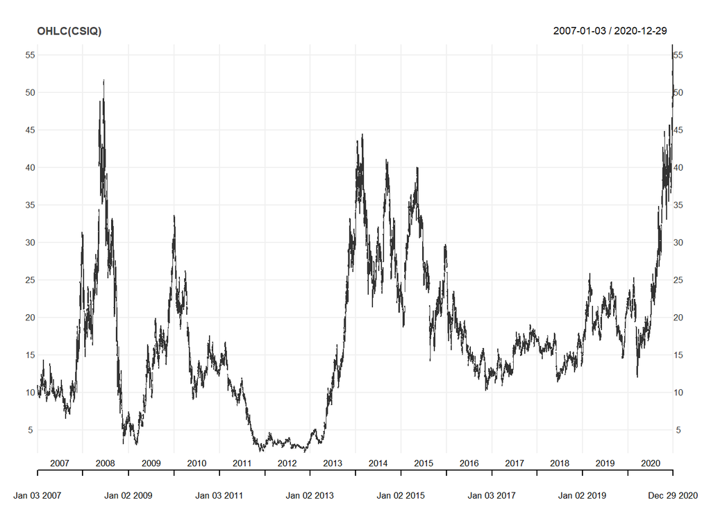

```r
## basic chart_Series from quantmod
chart_Series(OHLC(CSIQ))
```

- dygraph

```r
## use dygraphs pkg
dygraph(OHLC(CSIQ))
```

[interactive chart not shown]

- with volume

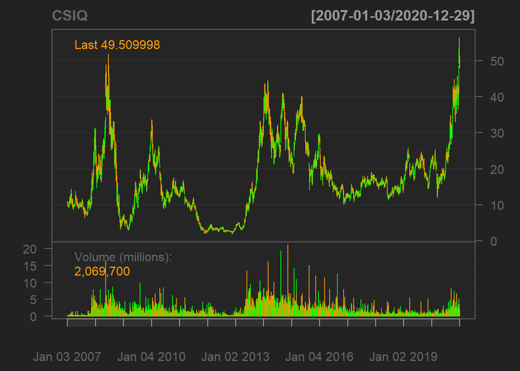

```r
barChart(CSIQ)
```

- closing price only

```r
# chart_Series(Cl(CSIQ)) #chart_Series seems to sometimes cause probs with pandoc(?)
dygraph(Cl(CSIQ))
```

[interactive chart not shown]

Easily add annotations

```r
graph <- dygraph(OHLC(CSIQ), main="Cdn Solar")
graph <- dyEvent(graph, "2020-02-21","Start of covid crash",
                 labelLoc="top")
graph
```

[interactive chart not shown]

Show only adjusted close, filtered for 2020

```r
CSIQ_2020 <- CSIQ['2020-01-01/']
graph <- dygraph(Ad(CSIQ_2020), main="Cdn Solar")
graph <- dyEvent(graph, "2020-02-21","Start of covid crash",
                 labelLoc="top")
graph
```

[interactive chart not shown]

## Adjusted price

Adjusted price is supposed to adjust for stock splits, while other prices are actual on the trading day.

However…Tesla (TSLA) had a 5-for-1 stock split on Aug 3 dropping price from ~$2,000 to ~$400. Prices collected as of Sep 5, 2020 show post-split throughout.

```r
getSymbols("TSLA", auto.assign = TRUE)
```

```
## [1] "TSLA"
```

```r
## filter for Aug, pre-split
TSLA_presplit <- TSLA['2020-08/2020-08-30']
tail(TSLA_presplit)
```

```
##            TSLA.Open TSLA.High TSLA.Low TSLA.Close TSLA.Volume
## 2020-08-21   408.952   419.098  405.010    409.996   107448000
## 2020-08-24   425.256   425.800  385.504    402.840   100318000
## 2020-08-25   394.978   405.590  393.600    404.668    53294500
## 2020-08-26   412.000   433.200  410.726    430.634    71197000
## 2020-08-27   436.092   459.120  428.500    447.750   118465000
## 2020-08-28   459.024   463.698  437.304    442.680   100406000
##            TSLA.Adjusted
## 2020-08-21       409.996
## 2020-08-24       402.840
## 2020-08-25       404.668
## 2020-08-26       430.634
## 2020-08-27       447.750
## 2020-08-28       442.680
```

```r
#chart_Series(OHLC(TSLA))
dygraph(OHLC(TSLA))
```

[interactive chart not shown]

## Candlestick

With selected period - in this case, based on recent (suitable up to ~30 days at a time).

```r
CSIQ_recent <- tail(CSIQ, n=30)
graph <- dygraph(OHLC(CSIQ_recent))
dyCandlestick(graph)
```

[interactive chart not shown]

- Open is either bottom of green bar OR top of red bar
- High is highest point (either line or top of bar)
- Low is lowest point (either line or bottom of bar)
- Close is either top of green bar OR bottom of red bar

## Add Technical features

- SMA: simple moving average
- MACD: moving average convergence divergence signals
- BBands: Bollinger bands
- other features are available in quantmod (not shown)

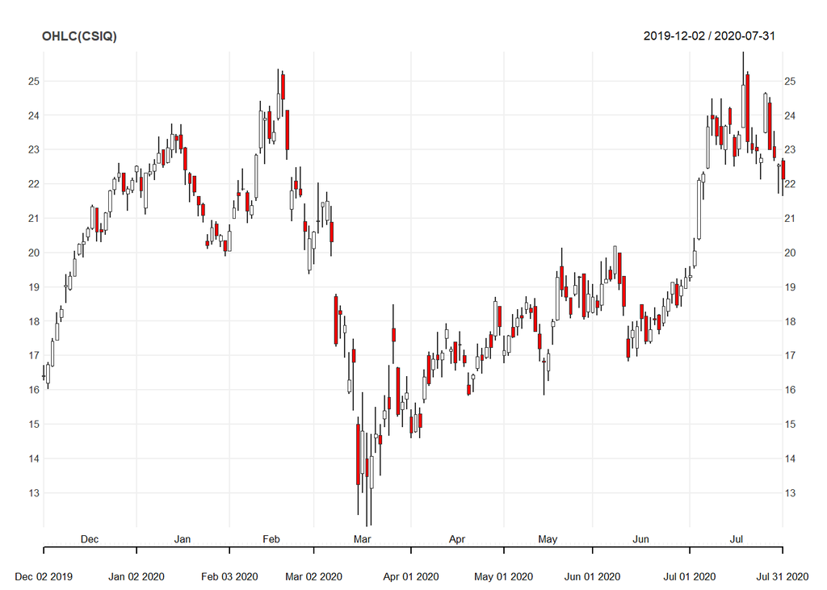

```r
chart_Series(OHLC(CSIQ), subset='2019-12/2020-07')
```

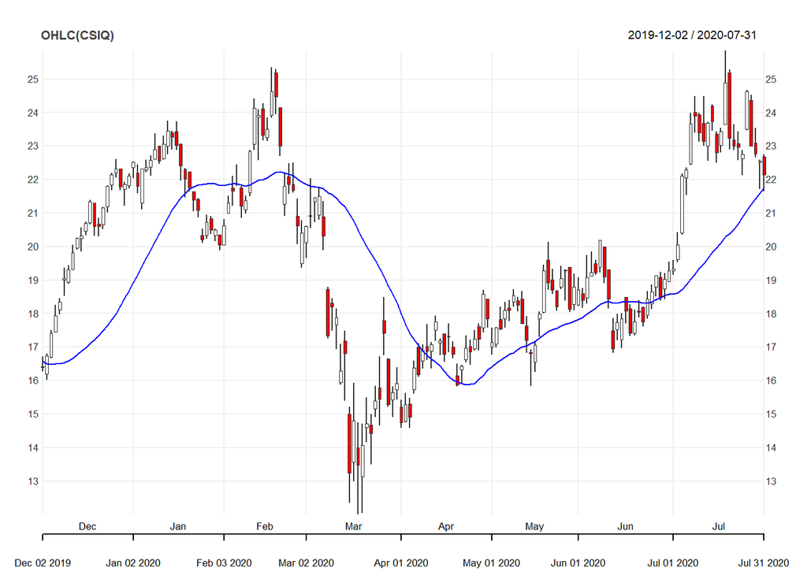

```r
add_SMA(n=30, col='blue')
```

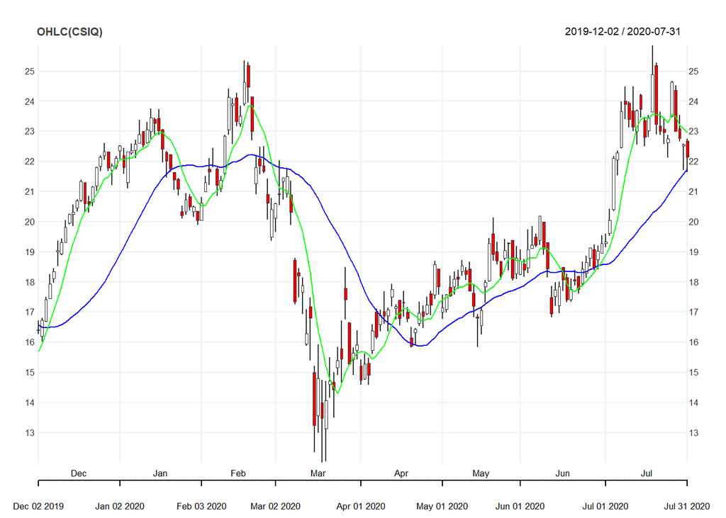

```r
add_SMA(n=7, col='green')
```

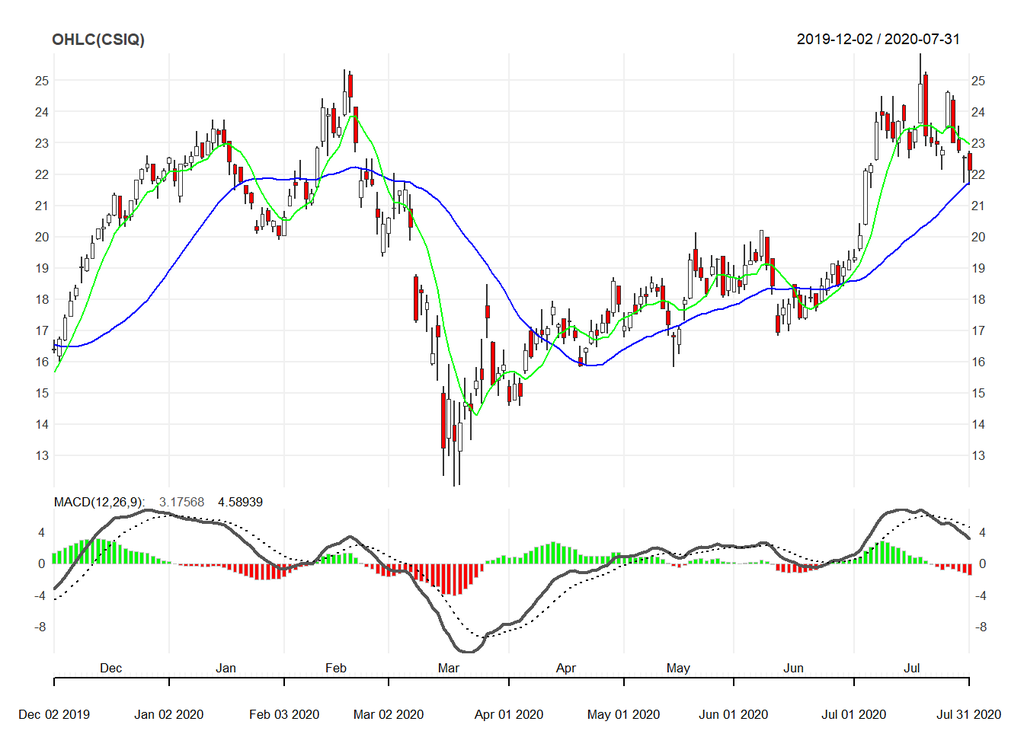

```r
add_MACD()
```

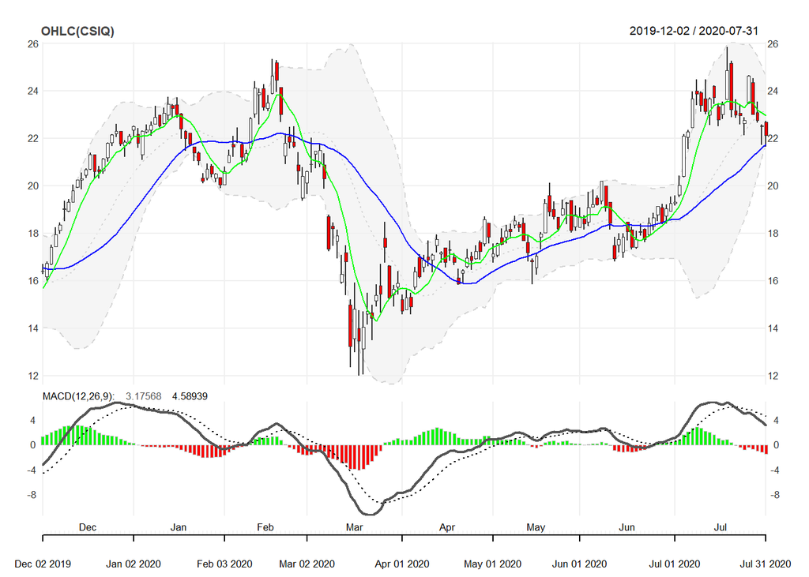

```r
add_BBands()
```

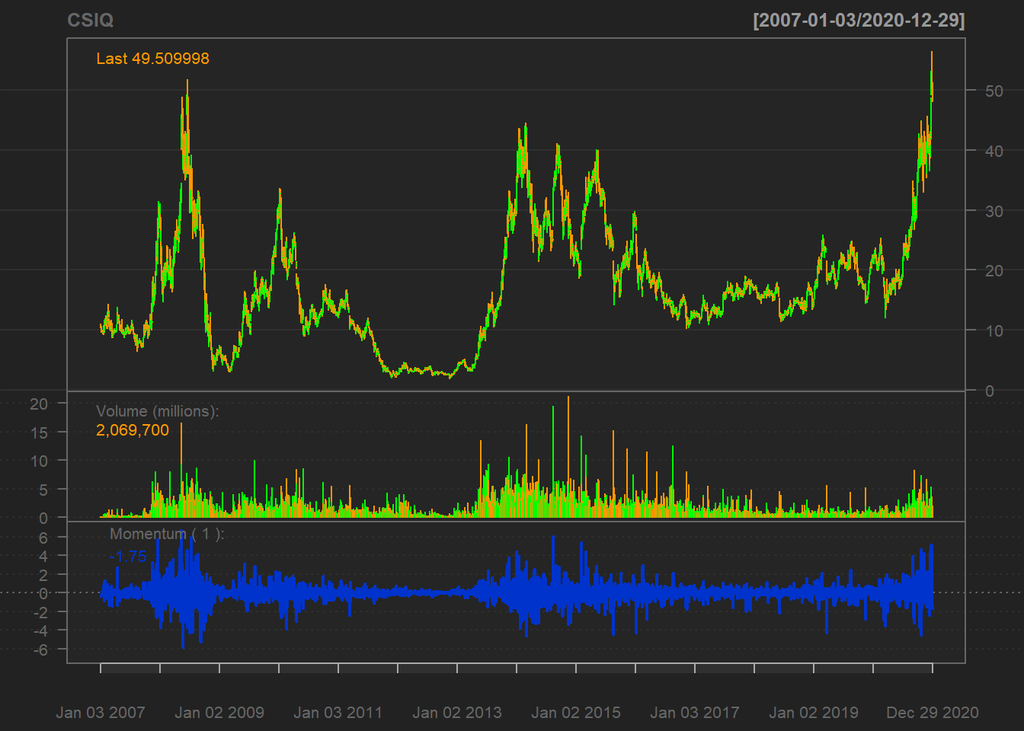

```r
addMomentum()
```

## Get Returns

```r
CSIQ_90d_return <- dailyReturn(CSIQ_90d)
dygraph(CSIQ_90d_return)
```

[interactive chart not shown]

### Stats on returns

```r
summary(CSIQ_90d_return)
```

```
##      Index            daily.returns
##  Min.   :2020-08-21   Min.   :-0.106232
##  1st Qu.:2020-09-23   1st Qu.:-0.018693
##  Median :2020-10-24   Median : 0.001407
##  Mean   :2020-10-24   Mean   : 0.008356
##  3rd Qu.:2020-11-24   3rd Qu.: 0.035254
##  Max.   :2020-12-29   Max.   : 0.135475
```

```r
sum(CSIQ_90d_return)
```

```
## [1] 0.7520005
```

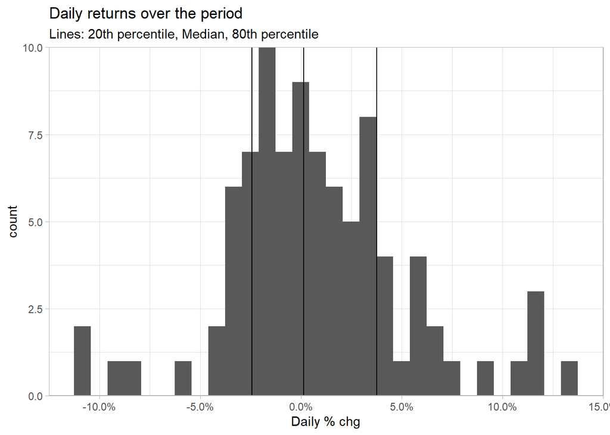

```r
ggplot(CSIQ_90d_return, aes(x=CSIQ_90d_return))+geom_histogram()+
  geom_vline(xintercept = median(CSIQ_90d_return))+
  geom_vline(xintercept = quantile(CSIQ_90d_return, 0.2))+
  geom_vline(xintercept = quantile(CSIQ_90d_return, 0.8))+
  scale_y_continuous(expand=c(0,0))+
  scale_x_continuous(labels=percent)+
  labs(title="Daily returns over the period",
       subtitle='Lines: 20th percentile, Median, 80th percentile',
       x='Daily % chg')
```

## Time Series Manipulation

Leverage xts to work with time series objects (probably warrants its own file)

### End points by period

- day, week, month, qtr, yr.
- returns the locations of each last item in the specified type of period, aligned on calendar.
- will include the last item available in the last period (last data point).
- returns a vector starting with 0 and ending with the extent (last row) of your data.
- can also use k to skip: on=‘years’, k=4 returns location of every 4th yr in data (plus last)

```r
## get index number of last day of each year
index_yr <- endpoints(CSIQ, on="years")
## apply to time series to extract selected end points
CSIQ_yr_end <- CSIQ[index_yr]
head(CSIQ_yr_end[,c(2,3,5)]) ## selected cols for space
```

```
##            CSIQ.High CSIQ.Low CSIQ.Volume
## 2007-12-31     29.15    27.26     1461900
## 2008-12-31      6.95     6.37     1024900
## 2009-12-31     29.44    28.81      686600
## 2010-12-31     12.41    12.12      510700
## 2011-12-30      2.70     2.53      350400
## 2012-12-31      3.43     3.25      506200
```

```r
index_week_end <- endpoints(CSIQ_Aug, on="weeks")
CSIQ_Aug[index_week_end, 1:4] ## open, high, low, close selected
```

```
##            CSIQ.Open CSIQ.High CSIQ.Low CSIQ.Close
## 2020-08-07     25.00     26.72    24.62      25.32
## 2020-08-14     26.41     26.41    25.51      25.89
## 2020-08-21     25.59     26.65    25.59      25.96
## 2020-08-28     29.25     32.72    28.92      32.52
## 2020-08-31     32.45     34.10    31.78      32.49
```

### Summarization

```r
##
period.apply(CSIQ_Aug, INDEX=index_week_end, FUN=mean)
```

```
##            CSIQ.Open CSIQ.High CSIQ.Low CSIQ.Close CSIQ.Volume
## 2020-08-07    23.526    24.352   23.142     23.822     1688020
## 2020-08-14    25.044    25.778   24.274     25.160     1739680
## 2020-08-21    26.142    26.854   25.756     26.176     1371340
## 2020-08-28    27.702    29.188   27.424     28.798     2473340
## 2020-08-31    32.450    34.100   31.780     32.490     2033100
##            CSIQ.Adjusted
## 2020-08-07        23.822
## 2020-08-14        25.160
## 2020-08-21        26.176
## 2020-08-28        28.798
## 2020-08-31        32.490
```

### Shortcut summarization

```r
## apply.weekly, apply.monthly, apply.quarterly, apply.yearly to summarize
## FUN=<whatever summarization function for the period)
apply.weekly(CSIQ_Aug, FUN=mean)
```

```
##            CSIQ.Open CSIQ.High CSIQ.Low CSIQ.Close CSIQ.Volume
## 2020-08-07    23.526    24.352   23.142     23.822     1688020
## 2020-08-14    25.044    25.778   24.274     25.160     1739680
## 2020-08-21    26.142    26.854   25.756     26.176     1371340
## 2020-08-28    27.702    29.188   27.424     28.798     2473340
## 2020-08-31    32.450    34.100   31.780     32.490     2033100
##            CSIQ.Adjusted
## 2020-08-07        23.822
## 2020-08-14        25.160
## 2020-08-21        26.176
## 2020-08-28        28.798
## 2020-08-31        32.490
```

### Split into periods

```r
## split data into weeks - chunk the data into 'week' components, without summarizing
CSIQ_Aug_weeks <- split(CSIQ_Aug, f='weeks')
## second week: high, low, close selected
CSIQ_Aug_weeks[[2]][,2:4]
```

```
##            CSIQ.High CSIQ.Low CSIQ.Close
## 2020-08-10     25.48    23.94      24.46
## 2020-08-11     24.72    23.32      24.04
## 2020-08-12     25.73    24.00      25.03
## 2020-08-13     26.55    24.60      26.38
## 2020-08-14     26.41    25.51      25.89
```

## Aggregate time periods

- Aggregate data by period
- Can take a single variable and calculate OHLC statistics by period

```r
CSIQ_yearly <- to.period(CSIQ[,6], period='years', name='CSIQ_adj', OHLC=TRUE)
CSIQ_yearly
```

```
##            CSIQ_adj.Open CSIQ_adj.High CSIQ_adj.Low CSIQ_adj.Close
## 2007-12-31         10.82         30.61         7.14          28.15
## 2008-12-31         28.67         51.00         3.78           6.46
## 2009-12-31          6.49         30.15         3.00          28.82
## 2010-12-31         30.99         32.71         9.20          12.39
## 2011-12-30         12.49         16.38         2.20           2.66
## 2012-12-31          2.80          4.39         2.03           3.40
## 2013-12-31          3.40         32.00         3.15          29.82
## 2014-12-31         34.19         43.67        21.11          24.19
## 2015-12-31         24.69         39.09        15.72          28.96
## 2016-12-30         27.98         27.98        10.65          12.18
## 2017-12-29         12.67         18.87        11.15          16.86
## 2018-12-31         17.14         17.75        11.87          14.34
## 2019-12-31         14.44         24.99        14.44          22.10
## 2020-12-29         22.52         53.16        13.24          49.51
```

### Shortcut aggregation

```r
CSIQ_2020_mth_agg <- to.monthly(CSIQ_2020[,6], name='CSIQ_adj')
CSIQ_2020_mth_agg
```

```
##          CSIQ_adj.Open CSIQ_adj.High CSIQ_adj.Low CSIQ_adj.Close
## Jan 2020         22.52         23.45        20.05          20.05
## Feb 2020         20.62         24.64        20.40          20.40
## Mar 2020         20.61         21.50        13.24          15.91
## Apr 2020         14.74         18.58        14.74          17.84
## May 2020         17.14         19.28        16.81          18.80
## Jun 2020         18.71         20.20        16.95          19.27
## Jul 2020         19.33         24.88        19.33          22.14
## Aug 2020         22.42         32.52        22.42          32.49
## Sep 2020         33.75         35.10        27.68          35.10
## Oct 2020         36.35         44.12        35.90          36.35
## Nov 2020         36.96         44.17        35.70          42.76
## Dec 2020         41.98         53.16        37.53          49.51
```

### Merging data with difference frequencies

```r
## get data -> DFF is daily Fed rate, FEDFUNDS is monthly
getSymbols(Symbols=c("FEDFUNDS","DFF"), src="FRED" )
```

```
## [1] "FEDFUNDS" "DFF"
```

```r
head(DFF) ## daily data
```

```
##             DFF
## 1954-07-01 1.13
## 1954-07-02 1.25
## 1954-07-03 1.25
## 1954-07-04 1.25
## 1954-07-05 0.88
## 1954-07-06 0.25
```

```r
head(FEDFUNDS) ## mthly data
```

```
##            FEDFUNDS
## 1954-07-01     0.80
## 1954-08-01     1.22
## 1954-09-01     1.07
## 1954-10-01     0.85
## 1954-11-01     0.83
## 1954-12-01     1.28
```

```r
## aggregate DFF to monthly by average
DFF_monthly <- apply.monthly(DFF, FUN=mean) ## FUN=aggregation calc
head(DFF_monthly) ## date as of end of month
```

```
##                  DFF
## 1954-07-31 0.7993548
## 1954-08-31 1.2206452
## 1954-09-30 1.0666667
## 1954-10-31 0.8487097
## 1954-11-30 0.8336667
## 1954-12-31 1.2777419
```

```r
## convert to monthly index
index(DFF_monthly) <- as.yearmon(index(DFF_monthly))

## mow can merge with data sets that have first of month
merged_funds <- merge(FEDFUNDS, DFF_monthly)
head(merged_funds)
```

```
##            FEDFUNDS       DFF
## 1954-07-01     0.80 0.7993548
## 1954-08-01     1.22 1.2206452
## 1954-09-01     1.07 1.0666667
## 1954-10-01     0.85 0.8487097
## 1954-11-01     0.83 0.8336667
## 1954-12-01     1.28 1.2777419
```

## Quandl for Importing

Claims ’the world’s most powerful data lives on [Quandl](https://www.quandl.com/). See also: [Quandl API documentation](https://docs.quandl.com/docs/getting-started).

- Economic data and similar
- Specify Source/Symbol
- Several ‘types’ available: deflaut is data.frame
- Does not appear that you can access stock prices without account/payment :(

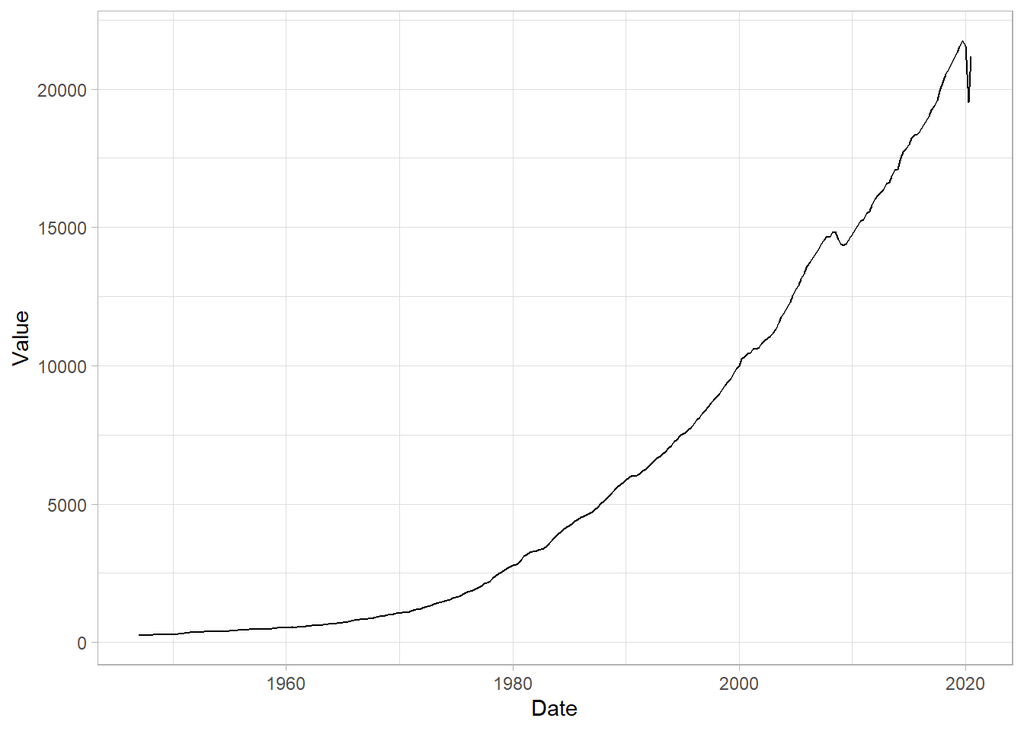

```r
us_gdp <- Quandl(code='FRED/GDP')

ggplot(us_gdp, aes(x=Date, y=Value))+geom_line()
```